# Nube de Palabras

D. S. Fernandez del Viso

7/8/2020

## Gráfica “word cloud” a partir de texto

Tomado de:

**Word cloud generator in R : One killer function to do everything you need - Easy Guides - Wiki - STHDA [WWW Document], n.d. URL** http://www.sthda.com/english/wiki/word-cloud-generator-in-r-one-killer-function-to-do-everything-you-need (accessed 7.8.20).

Paquetes necesarios:  
* tm  
* SnowballC  
* wordcloud  
* RColorBrewer  
* RCurl  
* XML

```r
## para instalar paquetes:
# install.packages(c("tm", "SnowballC", "wordcloud", "RColorBrewer", "RCurl", "XML"))
library(tm)
library(SnowballC)
library(wordcloud)
library(RColorBrewer)
library(RCurl)
library(XML)
library(rsconnect)
```

## Funciones necesarias para crear el “word cloud”

```r
# wordcloud function
rquery.wordcloud <- function(x, type=c("text", "url", "file"),
                          lang="english", excludeWords=NULL,
                          textStemming=FALSE, colorPalette="Dark2",
                          min.freq=3, max.words=200)
{
  library("tm")
  library("SnowballC")
  library("wordcloud")
  library("RColorBrewer")

  if(type[1]=="file") text <- readLines(x)
  else if(type[1]=="url") text <- html_to_text(x)
  else if(type[1]=="text") text <- x

  # Load the text as a corpus
  docs <- Corpus(VectorSource(text))
  # Convert the text to lower case
  docs <- tm_map(docs, content_transformer(tolower))
  # Remove numbers
  docs <- tm_map(docs, removeNumbers)
  # Remove stopwords for the language
  docs <- tm_map(docs, removeWords, stopwords(lang))
  # Remove punctuations
  docs <- tm_map(docs, removePunctuation)
  # Eliminate extra white spaces
  docs <- tm_map(docs, stripWhitespace)
  # Remove your own stopwords
  if(!is.null(excludeWords))
    docs <- tm_map(docs, removeWords, excludeWords)
  # Text stemming
  if(textStemming) docs <- tm_map(docs, stemDocument)
  # Create term-document matrix
  tdm <- TermDocumentMatrix(docs)
  m <- as.matrix(tdm)
  v <- sort(rowSums(m),decreasing=TRUE)
  d <- data.frame(word = names(v),freq=v)
  # check the color palette name
  if(!colorPalette %in% rownames(brewer.pal.info)) colors = colorPalette
  else colors = brewer.pal(8, colorPalette)
  # Plot the word cloud
  set.seed(1234)
  wordcloud(d$word,d$freq, min.freq=min.freq, max.words=max.words,
            random.order=FALSE, rot.per=0.35,
            use.r.layout=FALSE, colors=colors)

  invisible(list(tdm=tdm, freqTable = d))
}
# html_to_text function
html_to_text<-function(url){
  library(RCurl)
  library(XML)
  # download html
  html.doc <- getURL(url)
  #convert to plain text
  doc = htmlParse(html.doc, asText=TRUE)
 # "//text()" returns all text outside of HTML tags.
 # We also don’t want text such as style and script codes
  text <- xpathSApply(doc, "//text()[not(ancestor::script)][not(ancestor::style)][not(ancestor::noscript)][not(ancestor::form)]", xmlValue)
  # Format text vector into one character string
  return(paste(text, collapse = " "))
}
```

## Nube de palabras a partir de tres fuentes

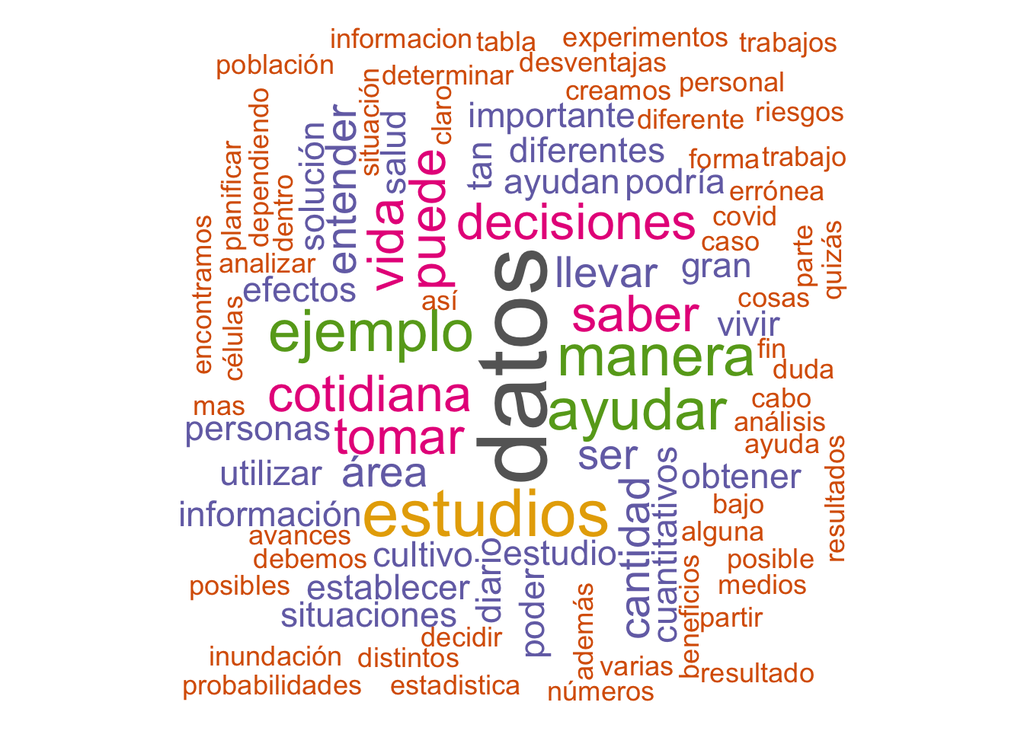

```r
# desde un url
deurl <- "https://dsfernandez.github.io/bioestadisticas/modulos/modulod1.html"
# desde texto
depath <- "url o dirección del archivo"
# desde vector de texto
detexto <- c("./Biometria_encuesta_estadisticas_20210118.txt")
## ejemplo de "wordcloud"
res <- rquery.wordcloud(detexto, type ="file",
                        lang = "spanish",
                        excludeWords = c("estadísticos", "estadisticas", "estadística", "estadísticas", "pueden", "vemos"),
                        textStemming = FALSE,
                        colorPalette = "Dark2",
                        min.freq = 2,
                        max.words = 500)
```

## Parámetros de la función

> **x** : character string (plain text, web URL, txt file path)  
> **type** : specify whether x is a plain text, a web page URL or a .txt file path  
> **lang** : the language of the text. This is important to be specified in order to remove the common stopwords (like ‘the’, ‘we’, ‘is’, ‘are’) from the text before further analysis. Supported languages are danish, dutch, english, finnish, french, german, hungarian, italian, norwegian, portuguese, russian, spanish and swedish.  
> **excludeWords** : a vector containing your own stopwords to be eliminated from the text. e.g : c(“word1”, “word2”)  
> **textStemming** : reduces words to their root form. Default value is FALSE. A stemming process reduces the words “moving” and “movement” to the root word, “move”.  
> **colorPalette** : Possible values are : a name of color palette taken from RColorBrewer package (e.g.: colorPalette = “Dark2”) color name (e.g. : colorPalette = “red”) a color code (e.g. : colorPalette = “#FF1245”)  
> **min.freq** : words with frequency below min.freq will not be plotted  
> **max.words** : maximum number of words to be plotted. least frequent terms dropped

## Análisis del texto

A partir de la función *rquery.wordcloud()* se pueden obtener dos objetos:  
* **tdm** : matriz de términos del documento  
* **freqTable** : tabla de frecuencias

### Tabla y gráfica de frecuencias

```r
# tabla de frecuencias (primeras 10 más frecuentes)
TablaFrecuencia <- res$freqTable
head(TablaFrecuencia, 20)
```

```
##                        word freq
## datos                 datos   11
## estudios           estudios    7
## ayudar               ayudar    6
## ejemplo             ejemplo    6
## manera               manera    6
## cotidiana         cotidiana    5
## decisiones       decisiones    5
## puede                 puede    5
## saber                 saber    5
## tomar                 tomar    5
## vida                   vida    5
## cantidad           cantidad    4
## entender           entender    4
## llevar               llevar    4
## ser                     ser    4
## área                   área    4
## ayudan               ayudan    3
## cuantitativos cuantitativos    3
## cultivo             cultivo    3
## diario               diario    3
```

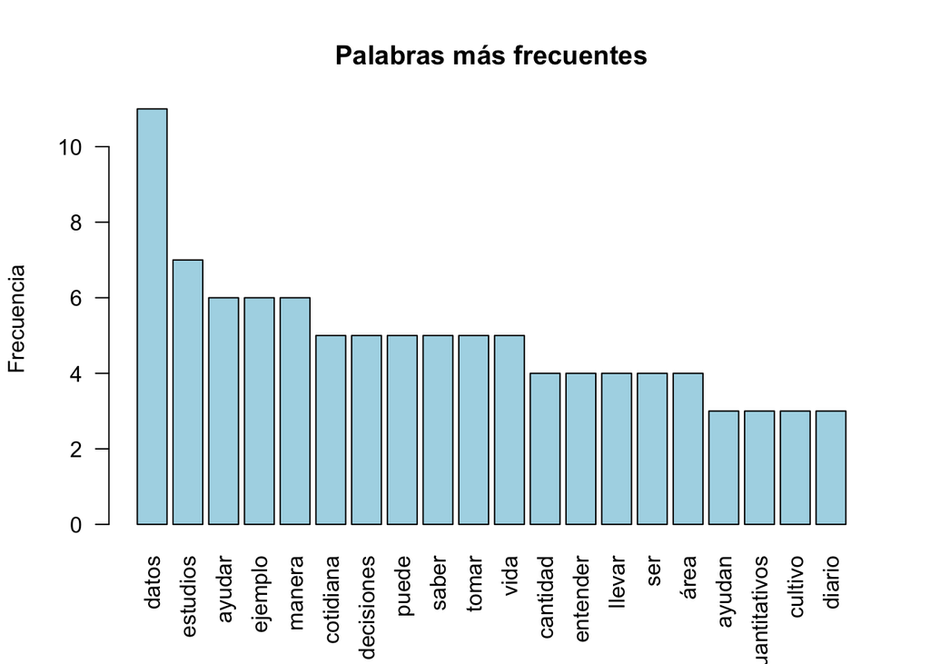

```r
# gráfica de frecuencias (primeras 10 palabras)
barplot(TablaFrecuencia[1:20,]$freq, las = 2,
        names.arg = TablaFrecuencia[1:20,]$word,
        col ="lightblue", main ="Palabras más frecuentes",
        ylab = "Frecuencia")
```

### Selección de palabras con cierta frecuencia

```r
# palabras que aparecen con cierta frecuencia
tdm <- res$tdm
findFreqTerms(tdm, lowfreq = 3)
```

```
##  [1] "ayudan"        "ayudar"        "cantidad"      "cotidiana"
##  [5] "cuantitativos" "cultivo"       "datos"         "decisiones"
##  [9] "diario"        "diferentes"    "efectos"       "ejemplo"
## [13] "entender"      "establecer"    "estudio"       "estudios"
## [17] "gran"          "importante"    "información"   "llevar"
## [21] "manera"        "obtener"       "personas"      "poder"
## [25] "podría"        "puede"         "saber"         "salud"
## [29] "ser"           "situaciones"   "solución"      "tan"
## [33] "tomar"         "utilizar"      "vida"          "vivir"
## [37] "área"
```

```r
# relación entre una palabra y otras
findAssocs(tdm, terms = "datos", corlimit = 0.0)
```

```
## $datos
## numeric(0)
```